# Modelo final: bondad de ajuste y capacidad predictiva

Claudia Segrera, Araceli Guillem y Pablo Escobar

### Introducción

Para acabar con el análisis del banco de datos vamos a estudiar la capacidad predictiva (RMSE) y la capacidad de ajuste (MSE) de los 4 mejores modelos de cada uno de los apartados comentado en el apartado de modelización.

### MSE Modelos Finales

Comenzamos midiendo el MSE del modelo 1 correspondiente al apartado de GLM. Dicho modelo presenta un MSE de $560.8996$:

```r
pred <- as.vector(predict(glm4nb, type="response"))
observ <- as.vector(glm4nb$y)
sum((observ - pred)^2)/length(abs(observ - pred))
```

```
## [1] 560.8996
```

A continuación, realizamos el mismo procedimiento para el modelo correspondiente al apartado de GLMM, que presenta un MSE de $688.2091$:

```r
pred <- as.vector(predict(gam3nb2$gam, type="response"))
observ <- as.vector(gam3nb2$lme$y)
sum((observ - pred)^2)/length(abs(observ - pred))
```

```
## [1] 688.2091
```

El siguiente modelo es el correspondiente a los modelos GAM, que tiene un MSE de $525.057$:

```r
pred <- as.vector(predict(suave1nb2, type="response"))
observ <- as.vector(suave1nb2$y)
sum((observ - pred)^2)/length(abs(observ - pred))
```

```
## [1] 525.057
```

Finalmente, el modelo perteneciente al apartado GAMM que hemos escogido como mejor modelo presenta un MSE de $545.6469$:

```r
pred <- as.vector(predict(gamm6nb2$gam, type="response"))
observ <- as.vector(gamm6nb2$lme$y)
sum((observ - pred)^2)/length(abs(observ - pred))
```

```
## [1] 545.6469
```

### RMSE Modelos Finales

De nuevo, empezamos con el modelo correspondiente al apartado de GLM, que presenta un RMSE de $28.26272$:

```r
cv_RMSE1 <- rep(NA,50)
for (i in 1:50){

  nums <- sample(1:600, 480, replace=FALSE)
  train <- datos[nums,]
  test <- datos[-(nums),]

  modelo <- glm(numero ~ fert + I(fert^2) + pluv, data=datos,family=negbin(theta = 3.154133, link="log"))


  predicciones <- as.vector(predict(modelo, newdata = test, type= "response"))

  cv_RMSE1[i] <- sqrt(mean((train$numero-predicciones)^2))
}
mean(cv_RMSE1)
```

```
## [1] 28.26272
```

```r
cv_RMSE2 <- rep(NA,50)
for (i in 1:50){

  nums <- sample(1:600, 480, replace=FALSE)
  train <- datos[nums,]
  test <- datos[-(nums),]

  modelo <- gamm(numero ~ pluv, data=datos, random=list(añosfac=~1+fert), family = negbin(link="log", theta=3.154133))


  predicciones <- as.vector(predict(modelo$gam, newdata = test, type= "response"))

  cv_RMSE2[i] <- sqrt(mean((train$numero-predicciones)^2))
}
```

```r
mean(cv_RMSE2)
```

```
## [1] 26.48485
```

A continuación, calculamos el RMSE del modelo perteneciente a los GAM que presenta un RMSE de $29.29555$:

```r
cv_RMSE3 <- rep(NA,50)
for (i in 1:50){

  nums <- sample(1:600, 480, replace=FALSE)
  train <- datos[nums,]
  test <- datos[-(nums),]

  modelo <- gam(numero ~ s(fert) + pluv, family=negbin(theta = 3.154133, link = "log"), data=datos)


  predicciones <- as.vector(predict(modelo, newdata = test, type= "response"))

  cv_RMSE3[i] <- sqrt(mean((train$numero-predicciones)^2))
}
```

```r
mean(cv_RMSE3)
```

```
## [1] 29.29555
```

Finalmente, calculamos el RMSE para nuestro mejor modelo correspondiente al apartado de GAMM, que es de $28.91798$:

```r
cv_RMSE4 <- rep(NA,50)
for (i in 1:50){

  nums <- sample(1:600, 480, replace=FALSE)
  train <- datos[nums,]
  test <- datos[-(nums),]

  modelo <- gamm(numero ~ s(fert) , data = datos, random=list(naranjo=~1), family=negbin(theta=3.154133, link="log"))


  predicciones <- as.vector(predict(modelo$gam, newdata = test, type= "response"))

  cv_RMSE4[i] <- sqrt(mean((train$numero-predicciones)^2))
}
```

```r
mean(cv_RMSE4)
```

```
## [1] 28.91798
```

### Conclusiones

A raíz de los resultados del MSE y RMSE para los 4 modelos podemos concluir que la capacidad de ajuste y la capacidad predictiva para todos ellos es similar y, además, ninguno de ellos es espcialmente bueno, con MSE que oscilan entre $500$ y $700$ y RMSE que oscilan entre $26$ y $29$. Con el fin de comprobar donde podría estar el problema hemos representado la media de naranjas producidas por cada uno de los 15 árboles así como los mínimos y máximos valores predichos por nuestro mejor modelo (GAMM) y podemos observar como los árboles 13 y 15 tienen medias que se encuentran por encima del intervalo de predicción.

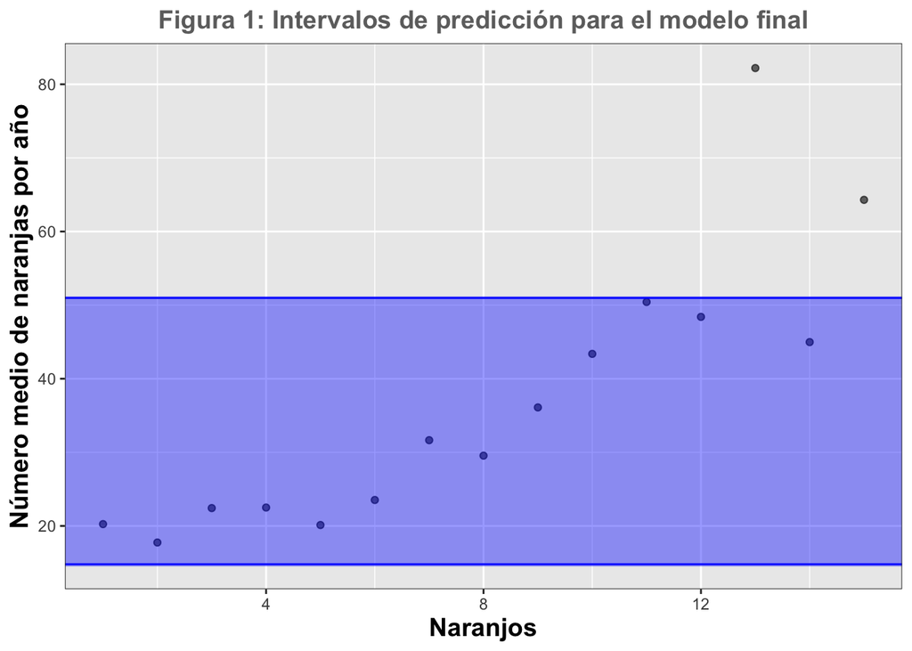

### ANEXO: *Capacidad Predictiva Sin Árboles Problemáticos*

A nivel anecdótico, hemos considerado que pasaría si eliminamos los árboles 13 y 15, que tienen valores muy extremos, del banco de datos. El modelo final generado a partir de este nuevo banco de datos sería el siguiente:

```r
gammC <- gamm(numero ~ s(fert), data = datos2, random=list(naranjo=~1), family=negbin(theta = 3.154133, link = "log"))
```

```
##
##  Maximum number of PQL iterations:  20
```

```
## iteration 1
```

```
## iteration 2
```

```
## iteration 3
```

Este modelo presenta un AIC mucho mejor que el de nuestros modelos con un valor de $365.8343$ y en las gráficas de residuos comprobamos que, ahora sí, parece que podemos asumir normalidad y homogeneidad de varianzas.

```
## Linear mixed-effects model fit by maximum likelihood
##  Data: data
##        AIC      BIC    logLik
##   365.8343 387.1034 -177.9171
##
## Random effects:
##  Formula: ~Xr - 1 | g
##  Structure: pdIdnot
##              Xr1      Xr2      Xr3      Xr4      Xr5      Xr6      Xr7      Xr8
## StdDev: 1.222402 1.222402 1.222402 1.222402 1.222402 1.222402 1.222402 1.222402
##
##  Formula: ~1 | naranjo %in% g
##         (Intercept)  Residual
## StdDev:   0.3863569 0.5315741
##
## Variance function:
##  Structure: fixed weights
##  Formula: ~invwt
## Fixed effects: list(fixed)
##                  Value Std.Error  DF   t-value p-value
## X(Intercept)  3.332928 0.1082660 506 30.784625  0.0000
## Xs(fert)Fx1  -0.546374 0.2008166 506 -2.720761  0.0067
##  Correlation:
##             X(Int)
## Xs(fert)Fx1 0.001
##
## Standardized Within-Group Residuals:
##         Min          Q1         Med          Q3         Max
## -2.25976704 -0.69888486 -0.09310207  0.57322032  4.13022668
##
## Number of Observations: 520
## Number of Groups:
##              g naranjo %in% g
##              1             13
```

```
##
## Family: Negative Binomial(3.154)
## Link function: log
##
## Formula:
## numero ~ s(fert)
##
## Parametric coefficients:
##             Estimate Std. Error t value Pr(>|t|)
## (Intercept)   3.3329     0.1082   30.81   <2e-16 ***
## ---
## Signif. codes:  0 '***' 0.001 '**' 0.01 '*' 0.05 '.' 0.1 ' ' 1
##
## Approximate significance of smooth terms:
##           edf Ref.df     F p-value
## s(fert) 6.168  6.168 97.15  <2e-16 ***
## ---
## Signif. codes:  0 '***' 0.001 '**' 0.01 '*' 0.05 '.' 0.1 ' ' 1
##
## R-sq.(adj) =   0.25
##   Scale est. = 0.28257   n = 520
```

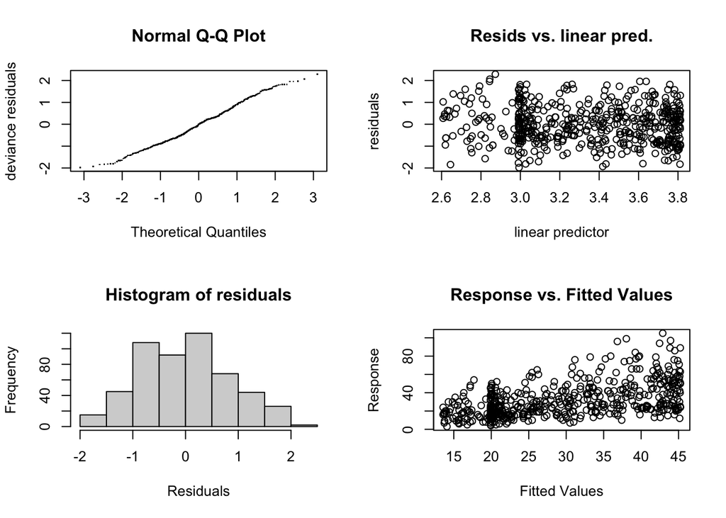

```
##
## 'gamm' based fit - care required with interpretation.
## Checks based on working residuals may be misleading.
## Basis dimension (k) checking results. Low p-value (k-index<1) may
## indicate that k is too low, especially if edf is close to k'.
##
##           k'  edf k-index p-value
## s(fert) 9.00 6.17    0.95     0.1
```

El MSE para este nuevo modelo es de $259.6397$:

```r
pred <- as.vector(predict(gammC$gam, type="response"))
observ <- as.vector(gammC$lme$y)
sum((observ - pred)^2)/length(abs(observ - pred))
```

```
## [1] 259.6397
```

```r
cv_RMSE <- rep(NA,50)
for (i in 1:50){

  nums <- sample(1:520, 416, replace=FALSE)
  train <- datos2[nums,]
  test <- datos2[-(nums),]

  modelo <- gamm(numero ~ s(fert), data = datos2, random=list(naranjo=~1), family=negbin(theta = 3.154133, link = "log"))

  predicciones <- as.vector(predict(modelo$gam, newdata = test, type= "response"))

  cv_RMSE[i] <- sqrt(mean((train$numero-predicciones)^2))
}
```

```r
mean(cv_RMSE)
```

```
## [1] 21.23229
```

Hemos considerado oportuno acabar este anexo comentando los resultados sobre la gráfica que incluye el intervalo de predicción. Podemos observar como ahora hay un par de árboles al final que sobresalen al haber disminuido la amplitud del intervalo de valores predichos pero, a diferencia del modelo anterior, la diferencia es pequeña. A nivel numérico confirmamos que, efectivamente, tanto el MSE como el RMSE son mucho más bajos.

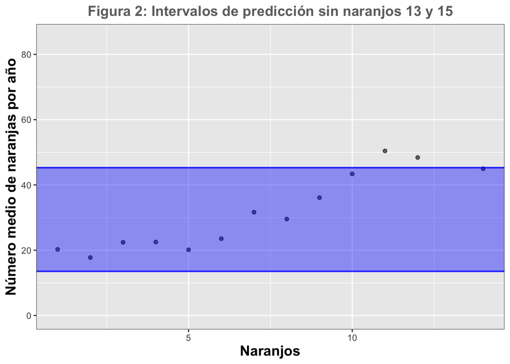

[Volver a la página principal](https://vdak1ng.github.io/Principal/)